# The determinants of the Council of ministers agenda

CAP Conference 2017, June 15-17

## Research question

**What factors drive the executive agenda between elections?**

**-> Party mandate**

**-> Responsiveness to real-world problems as signalled by the media**

## Study of executive agendas

- Policy output (legislative, budget)
- Symbolic agendas (Queen's/Prime Minister speeches)
- Decisions of the weekly Council of Ministers (through an analysis of press releases)

## Dependent variable: Council of minister agenda

- CoM decisions include:
  - adopting new legislation (either by adopting a bill to be submitted to Parliament, by using executive decrees or asking authorizations to legislate to the Parliament)
  - filling in the details of existing legislation through secondary measures
  - creating new agencies
  - signing international treaties
  - appointing officials

## Hypotheses on the Portuguese case:

- H1. Both the media and the electoral mandate as expressed in the majority platform are expected to influence the CoM agenda, but government platform agenda should have a stronger effect than that of media agenda
- H2. The main opposition parties' platform has a stronger influence on the CoM agenda than the challenger opposition platform
- H3. The influence of the majority platform on the CoM agenda is expected to increase in times of economic crisis

## Data

- Period: Portugal from 2002 to 2015 (4 legislatures)
- Executive agendas: 669 weekly press releases containing a total of 7419 decisions
- Party platforms: pledges included in each party platform of 5 major parties (Socialists and Social Democrats+Conservatives alternated in government, whereas Comunists and Left Bloc had not supported any cabinet until 2015)
- Economy index: overall unemployment rate + 10-year government bond yields (normalised because of different units of analysis)

## Distribution of Council of ministers decisions by topic (n=7419)

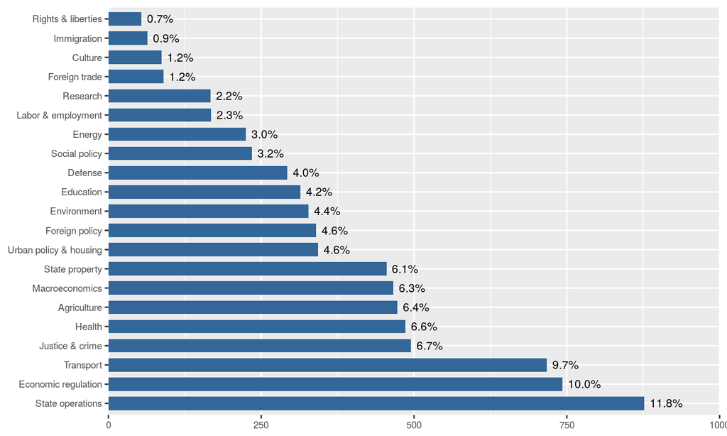

## Economy index

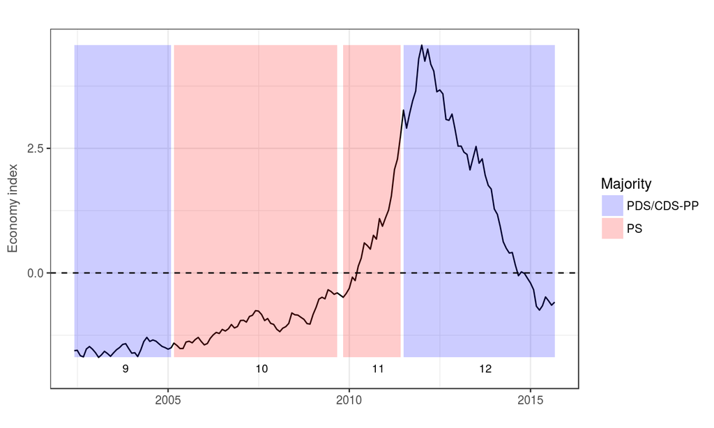

## TSCS analyses of CoM agendas

\(Gov_{it}\) = \(α_{0}\) + \(β1\) \(Media_{it-1}\) + \(β2\) \(Platform(Gov)_{ik-1}\) + \(β3\) \(Platform(Main Opp)_{ik-1}\) + \(β4\) \(Platform(Challenger)_{ik-1}\) + \(β5\) \(Gov_{it-1}\) + \(β6\) \(Gov_{it-12}\)

|  | **Model 1** | **Model 2** | **Model 3** |  |
| --- | --- | --- | --- | --- |
| \(Constant\) | 0.01*** | 0.01*** | 0.01*** |  |
|  | (0.00) | (0.00) | (0.00) |  |
| \(Gov_{it-1}\) | 0.22*** | 0.23*** | 0.22*** |  |
|  | (0.02) | (0.02) | (0.02) |  |
| \(Gov_{it-12}\) | 0.17*** | 0.18*** | 0.17*** |  |
|  | (0.02) | (0.02) | (0.02) |  |
| \(Media_{it-1}\) | 0.08** | 0.13*** | 0.07** |  |
|  | (0.03) | (0.02) | (0.03) |  |
| \(Platform(Gov)_{ik-1}\) | 0.23*** |  | 0.19*** |  |
|  | (0.03) |  | (0.04) |  |
| \(Platform(Main Opp)_{ik-1}\) |  | 0.14*** | 0.07** |  |
|  |  | (0.03) | (0.03) |  |
| \(Platform(Challenger)_{ik-1}\) |  | 0.06* | 0.01 |  |
|  |  | (0.03) | (0.03) |  |
| R<sup>2</sup> | 0.24 | 0.23 | 0.24 |  |
| Adj. R<sup>2</sup> | 0.24 | 0.23 | 0.24 |  |
| Num. obs. | 3087 | 3087 | 3087 |  |
| ***p < 0.001, **p < 0.01, *p < 0.05 |  |  |  |  |

## Interaction with economy index

|  | **Model 4** | **Model 5** | **Model 6** |  |
| --- | --- | --- | --- | --- |
| \(Constant\) | 0.02*** | 0.01*** | 0.01*** |  |
|  | (0.00) | (0.00) | (0.00) |  |
| \(Media_{it-1}\) | 0.08** | 0.13*** | 0.07** |  |
|  | (0.03) | (0.02) | (0.03) |  |
| \(Gov_{it-1}\) | 0.21*** | 0.22*** | 0.21*** |  |
|  | (0.02) | (0.02) | (0.02) |  |
| \(Gov_{it-12}\) | 0.17*** | 0.17*** | 0.16*** |  |
|  | (0.02) | (0.02) | (0.02) |  |
| \(Economy_{it-1}\) | -0.00* | -0.00 | -0.00 |  |
|  | (0.00) | (0.00) | (0.00) |  |
| \(Platform(Gov)_{ik-1}\) | 0.21*** |  | 0.15*** |  |
|  | (0.03) |  | (0.04) |  |
| \(Pf(Gov)_{ik-1} * Eco_{it-1}\) | 0.05** |  | 0.07*** |  |
|  | (0.02) |  | (0.02) |  |
| \(Media_{it-1} * Eco_{it-1}\) | -0.01 | 0.04** | -0.00 |  |
|  | (0.02) | (0.01) | (0.02) |  |
| \(Platform(Main Opp)_{ik-1}\) |  | 0.15*** | 0.11** |  |
|  |  | (0.03) | (0.04) |  |
| \(Platform(Challenger)_{ik-1}\) |  | 0.05 | 0.01 |  |
|  |  | (0.03) | (0.03) |  |
| \(Pf(Main Opp)_{ik-1} * Eco_{it-1}\) |  | -0.01 | -0.03 |  |
|  |  | (0.01) | (0.02) |  |
| \(Pf(Challenger)_{ik-1} * Eco_{it-1}\) |  | 0.00 | -0.01 |  |
|  |  | (0.02) | (0.02) |  |
| R<sup>2</sup> | 0.24 | 0.23 | 0.25 |  |
| Adj. R<sup>2</sup> | 0.24 | 0.23 | 0.24 |  |
| Num. obs. | 3087 | 3087 | 3087 |  |
| ***p < 0.001, **p < 0.01, *p < 0.05 |  |  |  |  |

## Interaction effect between attention in government platform and economy

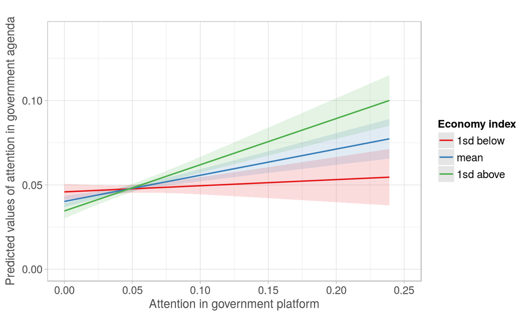

## Preliminary findings

- Both the media and the electoral mandate influence the CoM agenda, but government platform agenda does have a stronger effect than the media agenda (H1)
- Type of opposition matters: main opposition parties' platform has a stronger influence than the challenger opposition platform (H2)
- The influence of the majority platform on the CoM agenda increases in times of economic crisis (H3)

[figure not shown]